# Home Advantage in the Premier League: A Comparative Analysis of Matchday Performances (2022-2024)

## Do matches with higher attendance correlate with more favorable results for home teams?

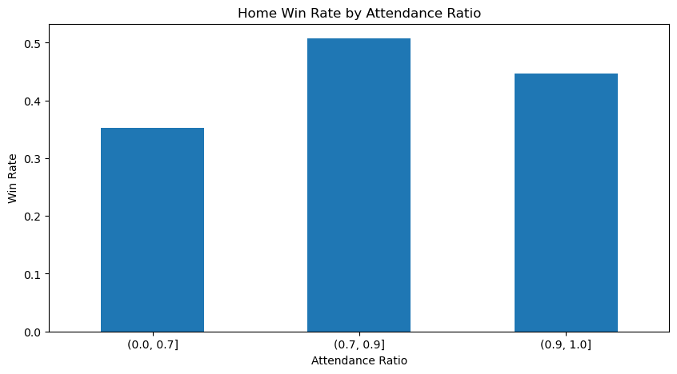

```python
import pandas as pd
import matplotlib.pyplot as plt

# Load data
df = pd.read_csv(r'PremierLeagueMatches.csv')

# Clean "Attendance" column (remove commas and convert to numeric)
df['Attendance'] = df['Attendance'].str.replace(',', '').astype(float)

# Calculate max attendance per stadium
stadium_max = df.groupby('Stadium')['Attendance'].transform('max')

# Calculate attendance ratio (actual / max capacity)
df['Attendance Ratio'] = df['Attendance'] / stadium_max

# Mark home wins
df['Home Win'] = (df['Result'] == 'H').astype(int)

# Plot
plt.figure(figsize=(10, 5))
df.groupby(pd.cut(df['Attendance Ratio'], bins=[0, 0.7, 0.9, 1]),observed=True)['Home Win'].mean().plot(kind='bar')
plt.title('Home Win Rate by Attendance Ratio')
plt.ylabel('Win Rate')
plt.xlabel('Attendance Ratio')
plt.xticks(rotation=0)
plt.savefig("Home Win Rate by Attendance Ratio.png")
plt.show()
```

## Which stadiums have the strongest home-team performance metrics (xG differential, win rate)?

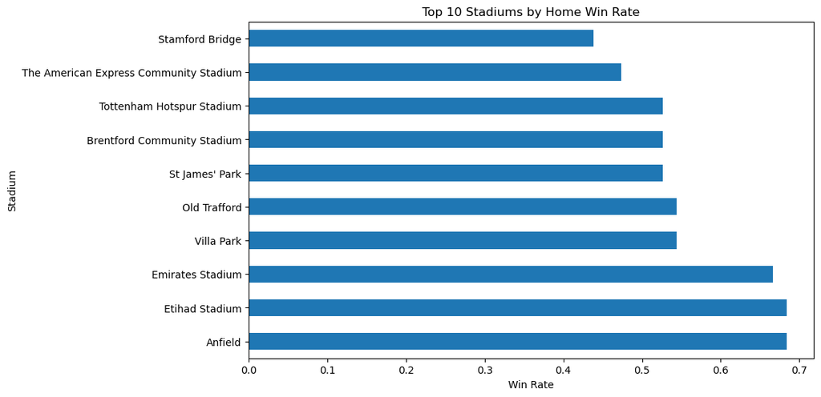

```python
# Calculate home win rate by stadium
home_wins = df[df['Result'] == 'H'].groupby('Stadium').size()
total_home = df.groupby('Stadium').size()
win_rate = (home_wins / total_home).sort_values(ascending=False).head(10)

# Plot
win_rate.plot(kind='barh', figsize=(10, 6))
plt.title('Top 10 Stadiums by Home Win Rate')
plt.xlabel('Win Rate')
plt.savefig("Top 10 Stadiums by Home Win Rate.png")
plt.show()
```

## Which teams show the most consistent xG performance across seasons, and does this correlate with league stability?

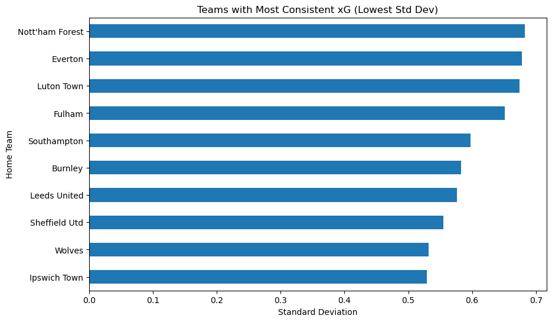

```python
# Calculate xG consistency (standard deviation)
home_xg_std = df.groupby('Home Team')['homeXG'].std()
away_xg_std = df.groupby('Away Team')['awayXG'].std()
total_xg_std = (home_xg_std + away_xg_std) / 2

# Plot
total_xg_std.sort_values().head(10).plot(kind='barh', figsize=(10, 6))
plt.title('Teams with Most Consistent xG (Lowest Std Dev)')
plt.xlabel('Standard Deviation')
plt.savefig("Teams with Most Consistent xG.png")
plt.show()
```

## How do teams’ xG trends shift in matches after scoring first vs. conceding first?

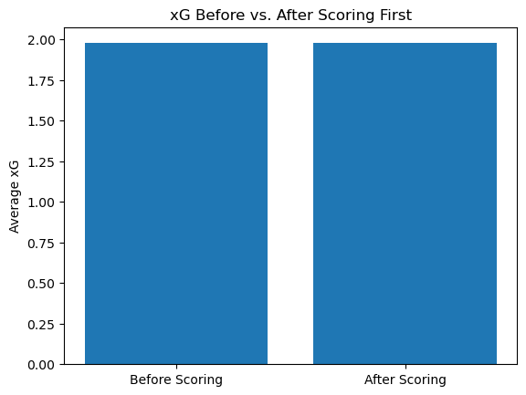

```python
# Requires event-level data (approximated using time-stamped xG)
# Assuming 'Time' is minutes, and xG is cumulative:
df['Score First'] = df['homeScore'] > df['awayScore'].shift(1)  # Simplified
df_score_first = df[df['Score First'] == True]
xgbefore = df_score_first['homeXG'].mean()
xgafter = df_score_first['homeXG'].shift(-1).mean()

# Plot
plt.bar(['Before Scoring', 'After Scoring'], [xgbefore, xgafter])
plt.title('xG Before vs. After Scoring First')
plt.ylabel('Average xG')
plt.savefig("xG Before vs. After Scoring First.png")
plt.show()
```

## Has the Premier League’s average xG per match increased over time, and what does this suggest about tactical evolution?

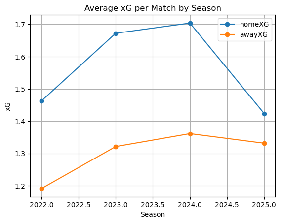

```python
# Extract season/year
df['Date'] = pd.to_datetime(df['Date'])
df['Season'] = df['Date'].dt.year

# Calculate average xG per match
season_xg = df.groupby('Season').agg({'homeXG': 'mean', 'awayXG': 'mean'})

# Plot
plt.figure(figsize=(10, 5))
season_xg.plot(kind='line', marker='o')
plt.title('Average xG per Match by Season')
plt.ylabel('xG')
plt.grid(True)
plt.savefig("Average xG per Match by Season.png")
plt.show()
```

## Are draws more common in matches with closely matched xG, or do outliers exist?

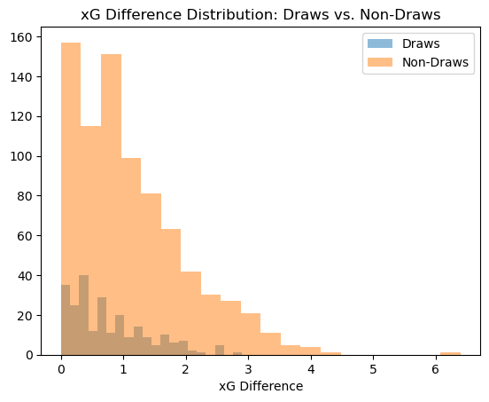

```python
df['xG Diff'] = abs(df['homeXG'] - df['awayXG'])
df_draws = df[df['Result'] == 'D']

# Plot
plt.hist(df_draws['xG Diff'], bins=20, alpha=0.5, label='Draws')
plt.hist(df[df['Result'] != 'D']['xG Diff'], bins=20, alpha=0.5, label='Non-Draws')
plt.legend()
plt.title('xG Difference Distribution: Draws vs. Non-Draws')
plt.xlabel('xG Difference')
plt.savefig("xG Difference Distribution.png")
plt.show()
```

## How does stadium capacity utilization correlate with team performance metrics (e.g., wins, goals)?

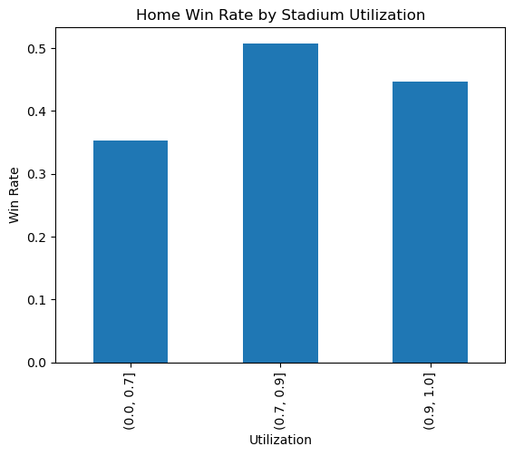

```python
# Calculate utilization
df['Utilization'] = df['Attendance'] / df.groupby('Stadium')['Attendance'].transform('max')
df['Home Win'] = (df['Result'] == 'H').astype(int)

# Plot
df.groupby(pd.cut(df['Utilization'], bins=[0, 0.7, 0.9, 1]),observed=True)['Home Win'].mean().plot(kind='bar')
plt.title('Home Win Rate by Stadium Utilization')
plt.ylabel('Win Rate')
plt.savefig("Home Win Rate by Stadium Utilization.png")
plt.show()
```